# CH6

JiangRan

6/23/2022

**8**. In this exercise, we will generate simulated data, and will then use this data to perform best subset selection.

1. Use the rnorm() function to generate a predictor $X$ of length $n$ = 100, as well as a noise vector $\epsilon$ of length $n$ = 100.

```r
set.seed(37)
x <- rnorm(100)
eps <- rnorm(100)
```

2. Generate a response vector Y of length n = 100 according to the model $Y = \beta_0 + \beta_1X + \beta_2X^2 + \beta_3X^3 +\epsilon$, where $\beta_0, \beta_1, \beta_2,\beta_3$ are constants of your choice.

```r
b0 <- 1
b1 <- 9
b2 <- 9
b3 <- 8
y <- b0 + b1*x + b2*x^2 + b3*x^3 + eps
```

3. Use the $regsubsets()$ function to perform best subset selection in order to choose the best model containing the predictors $X,X^2,...,X^{10}$. What is the best model obtained according to Cp, BIC, and adjusted R2? Show some plots to provide evidence for your answer, and report the coefficients of the best model obtained. Note you will need to use the $data.frame()$ function to create a single data set containing both $X$ and $Y$ ..

```r
library(leaps)
dat <- data.frame(y,x)
regfit.full <- regsubsets(y~poly(x,10), data=dat, nvmax = 19)
reg.summary <- summary(regfit.full)

par( mfrow=c(2,2) )
#C_p:min, BIC:min, adjR:max
minCP <- which.min(reg.summary$cp) #3
minBIC <- which.min(reg.summary$bic) #3
maxADJR <- which.max(reg.summary$adjr2) #4
#C_p
plot(reg.summary$cp, xlab = "number of variables", ylab = "CP", col="cyan3" ,type = "l" )
points(minCP, reg.summary$cp[minCP],col="grey",cex = 2, pch=20)
#BIC
plot(reg.summary$bic, xlab = "number of variables", ylab = "BIC", col="grey" ,type = "l" )
points(minBIC, reg.summary$bic[minBIC],col="orange",cex = 2, pch=20)
#adjR
plot(reg.summary$adjr2, xlab = "number of variables", ylab = "adjusted R^2", col="blue" ,type = "l" )
points(maxADJR, reg.summary$adjr2[maxADJR],col="pink",cex = 2, pch=20)

coef(regfit.full,3)
```

```
##  (Intercept) poly(x, 10)1 poly(x, 10)2 poly(x, 10)3
##     5.751359   297.849779    64.087601   147.617530
```

```r
coef(regfit.full,4)
```

```
##  (Intercept) poly(x, 10)1 poly(x, 10)2 poly(x, 10)3 poly(x, 10)8
##     5.751359   297.849779    64.087601   147.617530    -1.168786
```

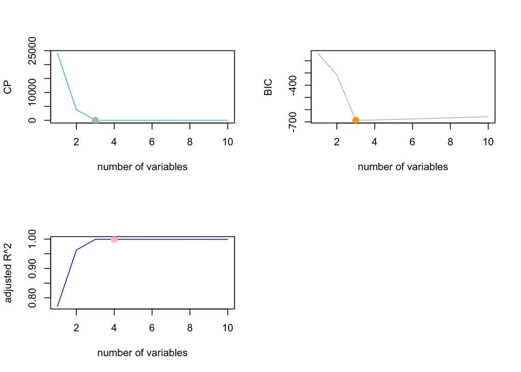

4. Repeat (c), using forward step-wise selection and also using backwards step-wise selection. How does your answer compare to the results in (c)?

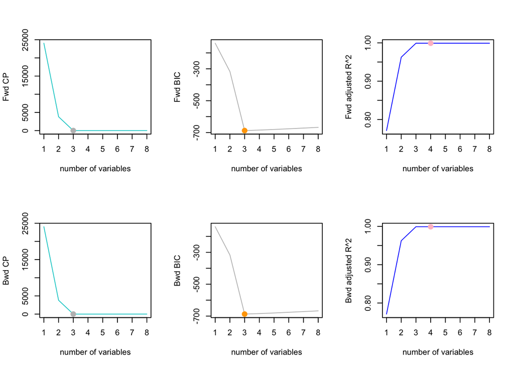

```r
regfit.forward <- regsubsets(y~poly(x,10), data=dat, method = "forward")
regfit.backward <- regsubsets(y~poly(x,10), data=dat, method = "backward")
regFwd.summary <- summary(regfit.forward)
regBwd.summary <- summary(regfit.backward)

par( mfrow=c(2,3) )
#C_p:min, BIC:min, adjR:max
#Forward
minCPFwd <- which.min(regFwd.summary$cp) #3
minBICFwd <- which.min(regFwd.summary$bic) #3
maxADJRFwd <- which.max(regFwd.summary$adjr2) #4
#C_p
plot(regFwd.summary$cp, xlab = "number of variables", ylab = "Fwd CP", col="cyan3" ,type = "l" )
points(minCPFwd, regFwd.summary$cp[minCPFwd],col="grey",cex = 2, pch=20)
#BIC
plot(regFwd.summary$bic, xlab = "number of variables", ylab = "Fwd BIC", col="grey" ,type = "l" )
points(minBICFwd, regFwd.summary$bic[minBICFwd],col="orange",cex = 2, pch=20)
#adjR
plot(regFwd.summary$adjr2, xlab = "number of variables", ylab = "Fwd adjusted R^2", col="blue" ,type = "l" )
points(maxADJRFwd, regFwd.summary$adjr2[maxADJRFwd],col="pink",cex = 2, pch=20)

#Backward
minCPBwd <- which.min(regBwd.summary$cp) #3
minBICBwd <- which.min(regBwd.summary$bic) #3
maxADJRBwd <- which.max(regBwd.summary$adjr2) #4
#C_p
plot(regBwd.summary$cp, xlab = "number of variables", ylab = "Bwd CP", col="cyan3" ,type = "l" )
points(minCPBwd, regFwd.summary$cp[minCPBwd],col="grey",cex = 2, pch=20)
#BIC
plot(regBwd.summary$bic, xlab = "number of variables", ylab = "Bwd BIC", col="grey" ,type = "l" )
points(minBICBwd, regBwd.summary$bic[minBICBwd],col="orange",cex = 2, pch=20)
#adjR
plot(regBwd.summary$adjr2, xlab = "number of variables", ylab = "Bwd adjusted R^2", col="blue" ,type = "l" )
points(maxADJRBwd, regBwd.summary$adjr2[maxADJRBwd],col="pink",cex = 2, pch=20)
```

```r
#forward coef
coef(regfit.forward,3)
```

```
##  (Intercept) poly(x, 10)1 poly(x, 10)2 poly(x, 10)3
##     5.751359   297.849779    64.087601   147.617530
```

```r
coef(regfit.forward,4)
```

```
##  (Intercept) poly(x, 10)1 poly(x, 10)2 poly(x, 10)3 poly(x, 10)8
##     5.751359   297.849779    64.087601   147.617530    -1.168786
```

```r
#backward coef
coef(regfit.backward,3)
```

```
##  (Intercept) poly(x, 10)1 poly(x, 10)2 poly(x, 10)3
##     5.751359   297.849779    64.087601   147.617530
```

```r
coef(regfit.backward,4)
```

```
##  (Intercept) poly(x, 10)1 poly(x, 10)2 poly(x, 10)3 poly(x, 10)8
##     5.751359   297.849779    64.087601   147.617530    -1.168786
```

5. Now fit a lasso model to the simulated data, again using $X,X^2, ..., X^{10}$ as predictors. Use cross-validation to select the optimal value of $\lambda$. Create plots of the cross$-$validation error as a function of $\lambda$. Report the resulting coefficient estimates, and discuss the results obtained.

```r
#lasso
library(glmnet)
```

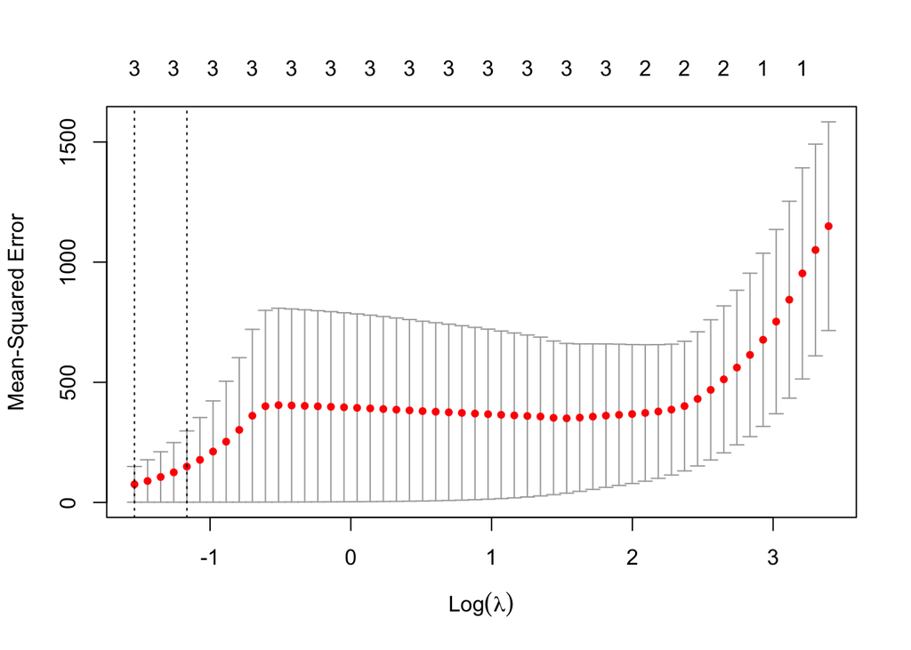

```r
X <- model.matrix(y~poly(x,10), data = dat)[,-1] # Cut down the Intercept column
# cv
cv.out <- cv.glmnet(X,y,alpha = 1)
plot(cv.out)
```

```r
# optimal lambda
minLambda <- cv.out$lambda.min
minLambda
```

```
## [1] 0.2150716
```

```r
# best lambda model
bestlasso.model <- glmnet(X,y,alpha = 1)
pred <- predict(bestlasso.model, s=minLambda, type="coefficients")
pred
```

```
## 11 x 1 sparse Matrix of class "dgCMatrix"
##                       s1
## (Intercept)     5.751359
## poly(x, 10)1  295.699063
## poly(x, 10)2   61.936885
## poly(x, 10)3  145.466813
## poly(x, 10)4    .
## poly(x, 10)5    .
## poly(x, 10)6    .
## poly(x, 10)7    .
## poly(x, 10)8    .
## poly(x, 10)9    .
## poly(x, 10)10   .
```

```r
# coefficients: beta1=295.699063, beta2=61.936885, beta3=145.466813
# the number of coefficients are compressed to only 3.
```

6. Now generate a response vector Y according to the model $Y = \beta_0 + \beta_7X^7 + \epsilon$, and perform best subset selection and the lasso. Discuss the results obtained.

```r
b7 <- 7
Y <- b0+b7*x^7+eps
set <- data.frame(x,Y)

### Best subset ###
regfit.best <- regsubsets(Y~poly(x,8),data = set, nvmax = 20)
reg.summary <- summary(regfit.best)

par( mfrow=c(2,2) )
#C_p:min, BIC:min, adjR:max
minCP <- which.min(reg.summary$cp) #7
minBIC <- which.min(reg.summary$bic) #7
maxADJR <- which.max(reg.summary$adjr2) #8
#C_p
plot(reg.summary$cp, xlab = "number of variables", ylab = "CP", col="cyan3" ,type = "l" )
points(minCP, reg.summary$cp[minCP],col="grey",cex = 2, pch=20)
#BIC
plot(reg.summary$bic, xlab = "number of variables", ylab = "BIC", col="grey" ,type = "l" )
points(minBIC, reg.summary$bic[minBIC],col="orange",cex = 2, pch=20)
#adjR
plot(reg.summary$adjr2, xlab = "number of variables", ylab = "adjusted R^2", col="blue" ,type = "l" )
points(maxADJR, reg.summary$adjr2[maxADJR],col="pink",cex = 2, pch=20)

coef(regfit.best,7)
```

```
## (Intercept) poly(x, 8)1 poly(x, 8)2 poly(x, 8)3 poly(x, 8)4 poly(x, 8)5
##   -111.9339   4591.1149  -2802.1493   6169.5235  -1820.0045   2769.8990
## poly(x, 8)6 poly(x, 8)7
##   -352.7334    368.2984
```

```r
coef(regfit.best,8)
```

```
##  (Intercept)  poly(x, 8)1  poly(x, 8)2  poly(x, 8)3  poly(x, 8)4  poly(x, 8)5
##  -111.933894  4591.114914 -2802.149333  6169.523516 -1820.004458  2769.898997
##  poly(x, 8)6  poly(x, 8)7  poly(x, 8)8
##  -352.733406   368.298366    -1.168786
```

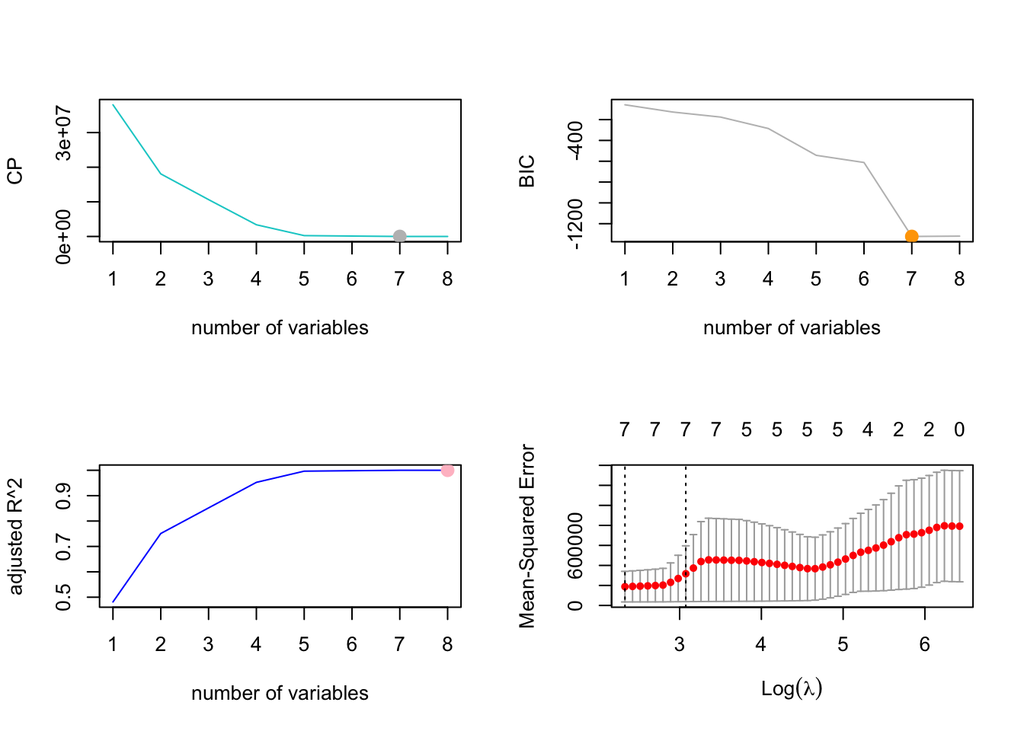

```r
### lasso ###
xMatrix <- model.matrix(Y~poly(x,8), data = set)
#find a best lambda by CV
cv.out <- cv.glmnet(xMatrix,Y,alpha = 1)
plot(cv.out)
```

```r
minLambda <- cv.out$lambda.min
```

**9**. In this exercise, we will predict the number of applications received using the other variables in the College data set.